# Regression and model validation

## Data wrangling

see chap2_wrangling.R

## Graphical overview of the data

### 1 The Data

```r
# load data
lrn14 <- read.csv("http://s3.amazonaws.com/assets.datacamp.com/production/course_2218/datasets/learning2014.txt", sep=",")
str (lrn14)
```

```
## 'data.frame':    166 obs. of  7 variables:
##  $ gender  : Factor w/ 2 levels "F","M": 1 2 1 2 2 1 2 1 2 1 ...
##  $ age     : int  53 55 49 53 49 38 50 37 37 42 ...
##  $ attitude: num  3.7 3.1 2.5 3.5 3.7 3.8 3.5 2.9 3.8 2.1 ...
##  $ deep    : num  3.58 2.92 3.5 3.5 3.67 ...
##  $ stra    : num  3.38 2.75 3.62 3.12 3.62 ...
##  $ surf    : num  2.58 3.17 2.25 2.25 2.83 ...
##  $ points  : int  25 12 24 10 22 21 21 31 24 26 ...
```

```r
dim (lrn14)
```

```
## [1] 166   7
```

The dataframe consists of 166 observations for 7 variables (gender, age, attitude, deep, stra, surf and points)

### 2 Graphs to visualize the overall relationships between all the selected variables

```r
##### load libraries
library(GGally)
```

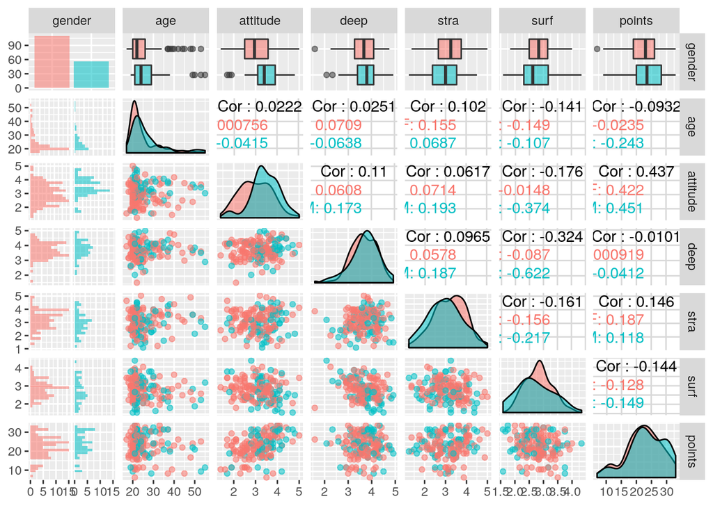

```r
library(ggplot2)

# draw all possible scatterplots to explore the data frame
plot_data <- ggpairs (lrn14, mapping = aes(col = gender, alpha = 0.3), lower = list(combo = wrap("facethist", bins = 20)))

####Draw the plot and summarise
plot_data
```

```r
summary(lrn14)
```

```
##  gender       age           attitude          deep            stra
##  F:110   Min.   :17.00   Min.   :1.400   Min.   :1.583   Min.   :1.250
##  M: 56   1st Qu.:21.00   1st Qu.:2.600   1st Qu.:3.333   1st Qu.:2.625
##          Median :22.00   Median :3.200   Median :3.667   Median :3.188
##          Mean   :25.51   Mean   :3.143   Mean   :3.680   Mean   :3.121
##          3rd Qu.:27.00   3rd Qu.:3.700   3rd Qu.:4.083   3rd Qu.:3.625
##          Max.   :55.00   Max.   :5.000   Max.   :4.917   Max.   :5.000
##       surf           points
##  Min.   :1.583   Min.   : 7.00
##  1st Qu.:2.417   1st Qu.:19.00
##  Median :2.833   Median :23.00
##  Mean   :2.787   Mean   :22.72
##  3rd Qu.:3.167   3rd Qu.:27.75
##  Max.   :4.333   Max.   :33.00
```

Total number of males are 50% less than females. Mainly in Attitude the differences between gender are more noticeable

Based in the previous observations it seems interesting to visualize how the attitute (that seems to vary most with gender) correlates with the acquired Points.

### 3 Regression model (exploration)

```r
regression_model <- lm(points ~ attitude + deep + stra + surf, data = lrn14)
summary(regression_model)
```

```
##
## Call:
## lm(formula = points ~ attitude + deep + stra + surf, data = lrn14)
##
## Residuals:
##      Min       1Q   Median       3Q      Max
## -16.7335  -3.1992   0.7975   3.4002  11.6582
##
## Coefficients:
##             Estimate Std. Error t value Pr(>|t|)
## (Intercept)  15.4000     5.0245   3.065  0.00255 **
## attitude      3.4362     0.5739   5.987 1.34e-08 ***
## deep         -1.0072     0.7870  -1.280  0.20247
## stra          0.8847     0.5411   1.635  0.10398
## surf         -0.9105     0.8390  -1.085  0.27948
## ---
## Signif. codes:  0 '***' 0.001 '**' 0.01 '*' 0.05 '.' 0.1 ' ' 1
##
## Residual standard error: 5.286 on 161 degrees of freedom
## Multiple R-squared:  0.2154, Adjusted R-squared:  0.1959
## F-statistic: 11.05 on 4 and 161 DF,  p-value: 6.057e-08
```

In this multivariant analysis, we “measure” points against attitude, deep, stra and surf i.e. the explainatory variables and see that points have significant relationship with attitude. R-squared value of 0.22 implies that the model can explain 22% of the variation in the outcome.

### 3 Regression model (new)

```r
new_regression_model <- lm(points ~ attitude, data = lrn14)
summary(new_regression_model)
```

```
##
## Call:
## lm(formula = points ~ attitude, data = lrn14)
##
## Residuals:
##      Min       1Q   Median       3Q      Max
## -16.9763  -3.2119   0.4339   4.1534  10.6645
##
## Coefficients:
##             Estimate Std. Error t value Pr(>|t|)
## (Intercept)  11.6372     1.8303   6.358 1.95e-09 ***
## attitude      3.5255     0.5674   6.214 4.12e-09 ***
## ---
## Signif. codes:  0 '***' 0.001 '**' 0.01 '*' 0.05 '.' 0.1 ' ' 1
##
## Residual standard error: 5.32 on 164 degrees of freedom
## Multiple R-squared:  0.1906, Adjusted R-squared:  0.1856
## F-statistic: 38.61 on 1 and 164 DF,  p-value: 4.119e-09
```

### 4 Interpret the model parameters after removing non-significant parameters

```r
summary(new_regression_model)
```

```
##
## Call:
## lm(formula = points ~ attitude, data = lrn14)
##
## Residuals:
##      Min       1Q   Median       3Q      Max
## -16.9763  -3.2119   0.4339   4.1534  10.6645
##
## Coefficients:
##             Estimate Std. Error t value Pr(>|t|)
## (Intercept)  11.6372     1.8303   6.358 1.95e-09 ***
## attitude      3.5255     0.5674   6.214 4.12e-09 ***
## ---
## Signif. codes:  0 '***' 0.001 '**' 0.01 '*' 0.05 '.' 0.1 ' ' 1
##
## Residual standard error: 5.32 on 164 degrees of freedom
## Multiple R-squared:  0.1906, Adjusted R-squared:  0.1856
## F-statistic: 38.61 on 1 and 164 DF,  p-value: 4.119e-09
```

Points is significantly related to attitude Multiple R-squared: 0.1906 R-squared = Explained variation / Total variation Multiple R-squared is used for evaluating how well the model fits the data. In this case, R-squared value of 0.19 implies that the model can explain only 19% of the variation in the outcome.

### 5 Diagnostic plots

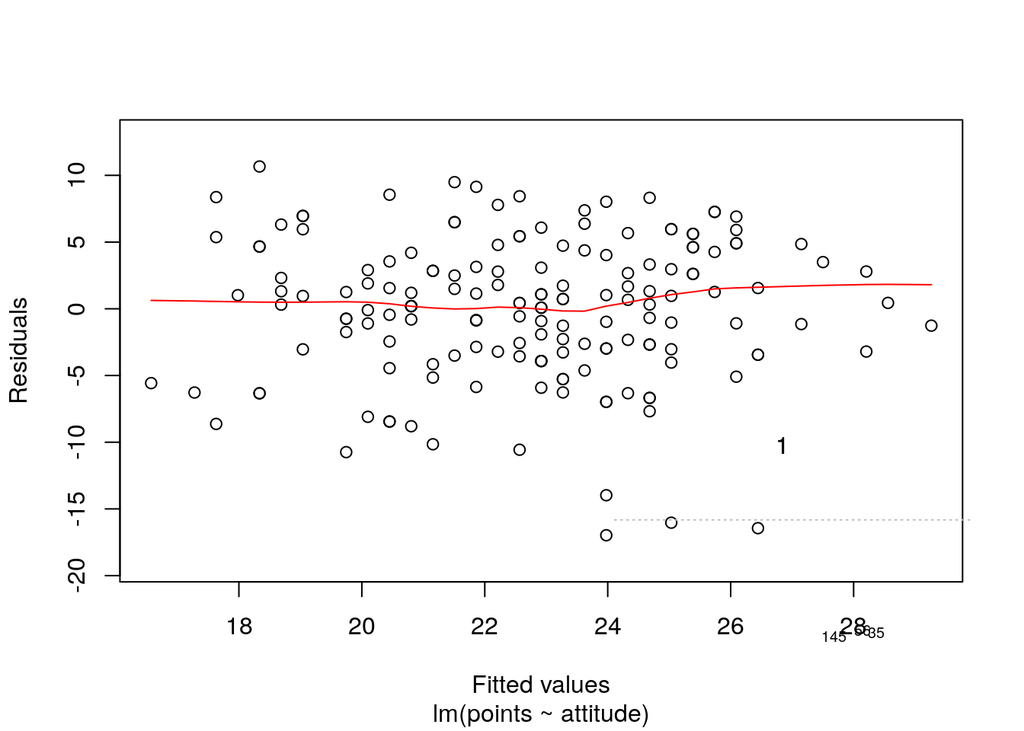

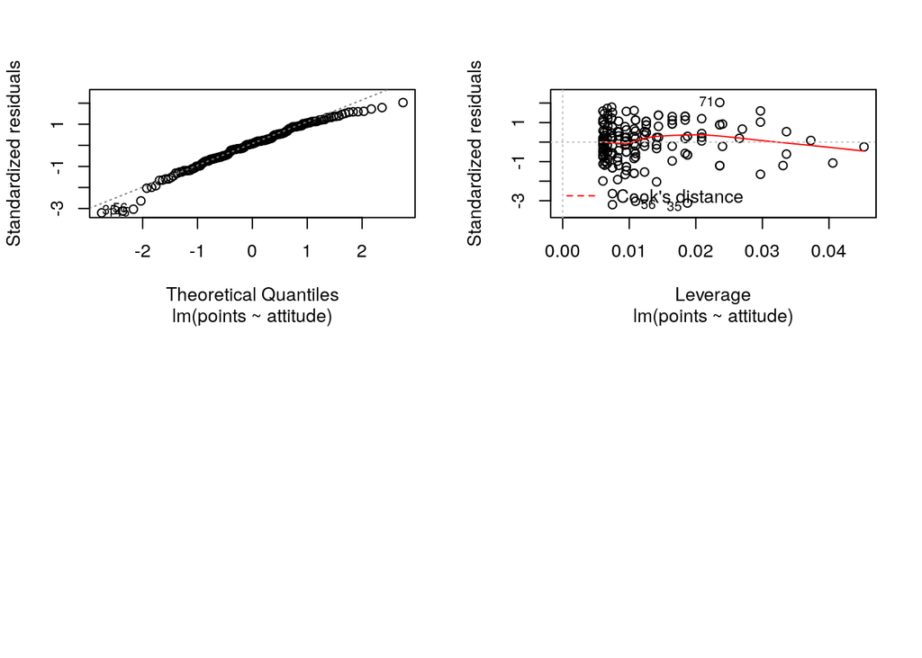

```r
plot(new_regression_model, which = c(1, 2, 5), par(mfrow = c(2,2)) )
```

Assumptions of the model: 1. How well does the model describs the variables we are interested in 2. The target variable is a linear combination of the model parameters 3. Errors are normally disrtibuted, not correlated and have constant variance

Residual vs Fitted plot explains about variance in errors. We can see that some errors deviate from the regression line implying that there is issue with the model.

QQplot shows that most points fall close to the line but some points are not close on the left hand side of the graph, hence the fit is somewhere near to the normality assumption. The model is reasonably okay.